# Randomization Tests for an ANOVA

## Goal of a Hypothesis Test for Many Means

An ANOVA seeks to assess the differences in the group means relative to the variability in the observations within each group.

Ideally, we’d like to see:

- large differences in the means of the groups
- small amounts of variability within each group

## Hypotheses

ANOVA uses a single hypothesis test to check whether the means across many groups are equal:

\(H_0\): The mean outcome is the same across all groups.

*OR*

\(H_0\): \(\mu_1 = \mu_2 = \cdots = \mu_k,\) where \(\mu_i\) represents the mean of the response for observations in category \(i\).

\(H_A\): At least one mean (\(\mu_i\)) is different.

## Model Conditions

Before performing an ANOVA, there are three conditions we must check:

- the observations are independent within and across groups
- the data within each group are nearly normal
- the variability across the groups is similar

## Calculating an Observed Statistic

We need a statistic that captures:

1. how different the group of means are from each other
2. how variable the observations of the groups are

The \(F\)-statistic does just this!

It is the ratio of the variability *between* the groups to the variability *within* the groups.

\[ F = \frac{MSG}{MSE} \]

## Null Hypothesis

An ANOVA focuses on answering one question: is the variability in the sample means so large that it seems unlikely to be from chance alone?

If the null hypothesis is true, any differences among the sample means are only due to chance. This would mean that the \(MSG\) and \(MSE\) should be about equal.

- This means, if the null hypothesis is true, we’d expect an \(F\)-statistic of about 1.

## Exam Scores

Suppose now that the teacher had had such an extremely large class that three different exams were given: A, B, and C. We’d like to investigate whether or not the difficultly of the exams is the same across the three exams.

So, our test would be:

\(H_0\): \(\mu_A = \mu_B = \mu_C\); The inherent average difficulty is the same across the three exams.

\(H_A\): at least one \(\mu_i\) (i = A, B, C) is different; At least one of the exams is inherently more (or less) difficult than the others.

## Exploratory Visualization

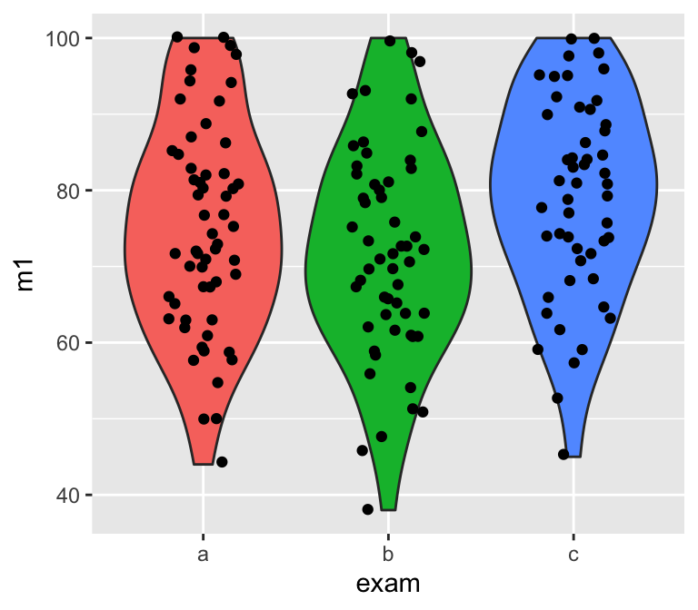

```r
classdata %>%
  ggplot(aes(x = exam, y = m1)) +
  geom_violin(aes(fill = exam)) +
  geom_jitter(width = 0.2) +
  theme(legend.position = "none")
```

## Randomization Test

- If the null hypothesis is true, then the score on each exam should represent the true student ability on that material.
- It shouldn’t matter whether a student took exam A or exam B or exam C.
- By reallocating which student got which exam, we are able to understand how the difference in average exam scores changes due only to natural variability.

## Using infer

We have the same steps as before, the only modifications are to the statistic calculated for each permutation.

```r
null_dist <- classdata %>%
  specify(m1 ~ exam) %>%
  hypothesise(null = "independence") %>%
  generate(reps = 2000, type = "permute") %>%
  calculate(stat = "F")
```

## Visualizing the Null Distribution

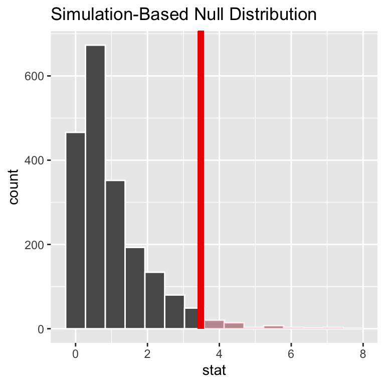

```r
obs_F <- classdata %>%
  specify(m1 ~ exam) %>%
  calculate(stat = "F")

null_dist %>%
  visualise() +
  geom_vline(xintercept = obs_F)
```

## Calculating the p-value

```r
null_dist %>%
  get_p_value(obs_stat = obs_F, direction = "greater")
```

```
## # A tibble: 1 x 1
##   p_value
##     <dbl>
## 1   0.029
```

- What would you conclude?
- Which exam seemed different from the others?